# Association between sentiment scores and T-500 self-reported scores in Mood/Anxiety group

Saeid Parvandeh

October 2017

-The compound score is computed by summing the valence scores of each word in the lexicon, adjusted according to the rules, and then normalized to be between -1 (most extreme negative) and +1 (most extreme positive)

-The positive, objectivity, and negative scores are ratios for proportions of text that fall in each category.

In this report, we investigate the association of these four scores, adjusted by total number of sentences, with self-reposted scores in T-500 data base for mood/anxitey group.

- Number of subjects in mood/axiety.

```
## [1] 194
```

A simple example to show how the analysis work. The following sentences selected from T-500 narrative reports:

```
## ####################################
```

The subject was born in Boston and her family moved to Tulsa when she was 5 years old. She stated that she and her sister were teased constantly throughout elementary school because of their accents. She stated that she was overweight and would be called “hippo” by fellow students. She said that the teasing impacted her deeply and her self esteem suffered as a result. She stated that in order to fit in with her classmates, she began using marijuana and alcohol at 14 years old. She would smoke daily and drink occasionally at parties. She began acting out soon after her drug use began and started getting in trouble at school. She eventually ran away from home for 3 days due to the tension in the home between her and her mother. At 16 years old she got pregnant and was “forced to abort the baby” by her mother. She reports being given an ultimatum by her mother to either abort the child or be thrown out of the home and onto the street.

fit (Polarity = 1.5, Intensity = 1.0247)

forced (Polarity = -2.0, Intensity = 0.63246)

overweight (Polarity = -1.5, Intensity = 0.67082)

parties (Polarity = 1.7, Intensity = 0.78102)

suffered (Polarity = -2.2, Intensity = 0.74833)

teased (Polarity = -1.2, Intensity = 0.87178)

teasing (Polarity = -0.3, Intensity = 1.1)

tension (Polarity = -1.3, Intensity = 1.00499)

trouble (Polarity = -1.7, Intensity = 0.64031)

- Three random sentences:
1. Grew up in New Jersey, one of 9 children.

Polarity: 0.0, Negative: 0.0, objectivity: 1.0, Positive: 0.0,

2. At 14 years old, the subject’s mother attempted suicide and was hospitalized for several weeks.

Valence words: (“suicide”, polarity: -3.5, intensity: 0.67082)

Polarity: -0.6705, Negative: 0.243, objectivity: 0.757, Positive: 0.0,

3. She reports currently being happy and functioning well.

Valence words: (“happy”, polarity: 2.7, intensity: 0.9, “well”, polarity: 1.1, intensity: 1.04403)

Polarity: 0.7003, Negative: 0.0, objectivity: 0.508, Positive: 0.492,

```
## ####################################
```

Correlation between dependend scores:

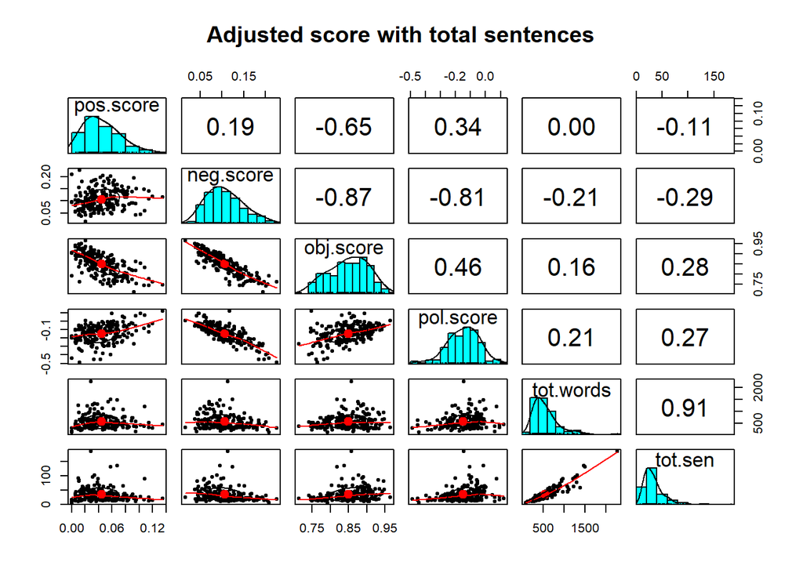

Histogram of dependent scores:

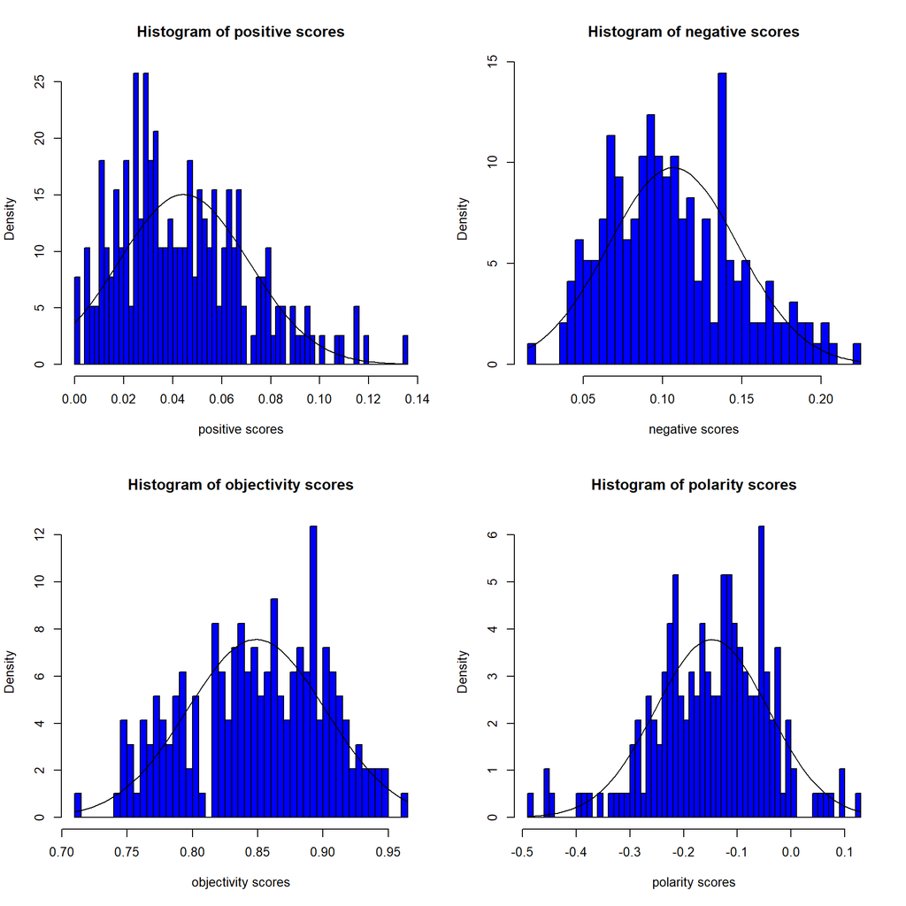

- Interviewers effect on dependet scores:

```
##           Df    Pr(>F)
## tot.sen    1 0.0052825 **
## tot.words  1 3.146e-11 ***
## pos.score  1 0.0002122 ***
## neg.score  1 0.6739006
## obj.score  1 0.6297289
## pol.score  1 0.1801735
## ---
## Signif. codes:  0 '***' 0.001 '**' 0.01 '*' 0.05 '.' 0.1 ' ' 1
```

Determine the degree to which socio-demographic characteristics effect the dependent scores

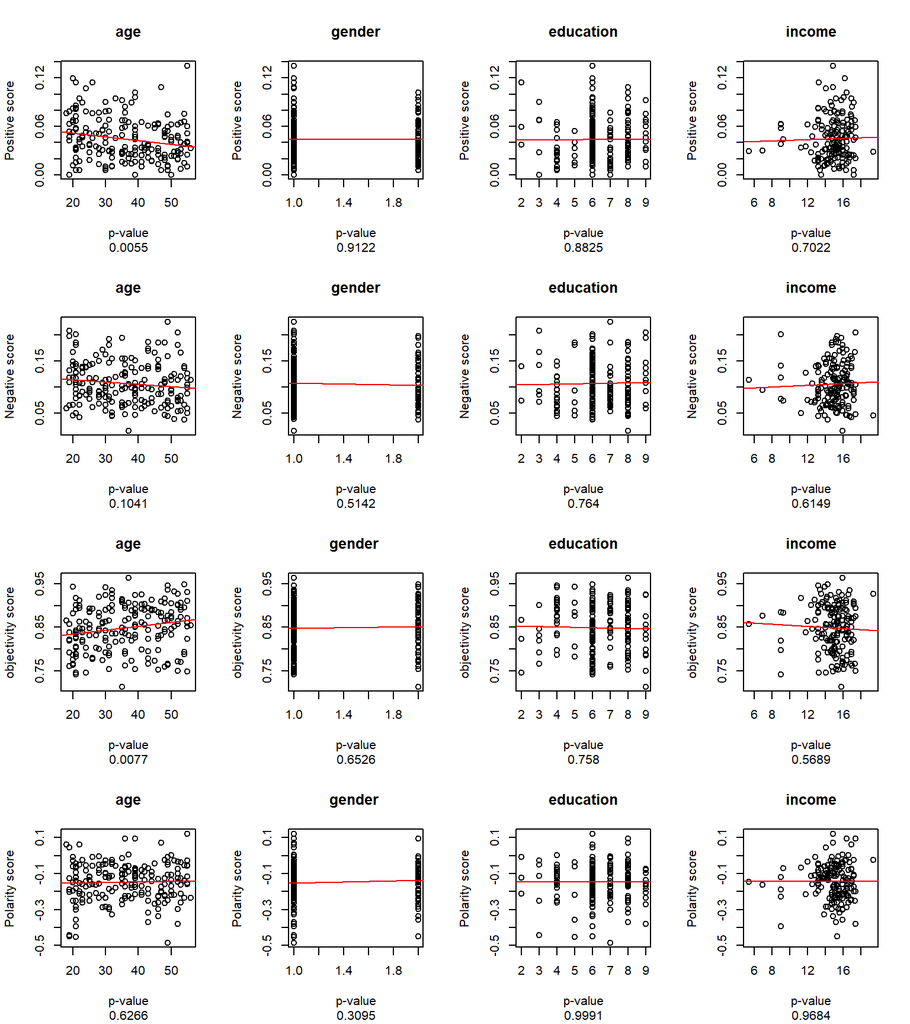

Determine the relationship with respect to the following trait variables: (PANAS-X, BIF, Symptom scales PHQ-9)

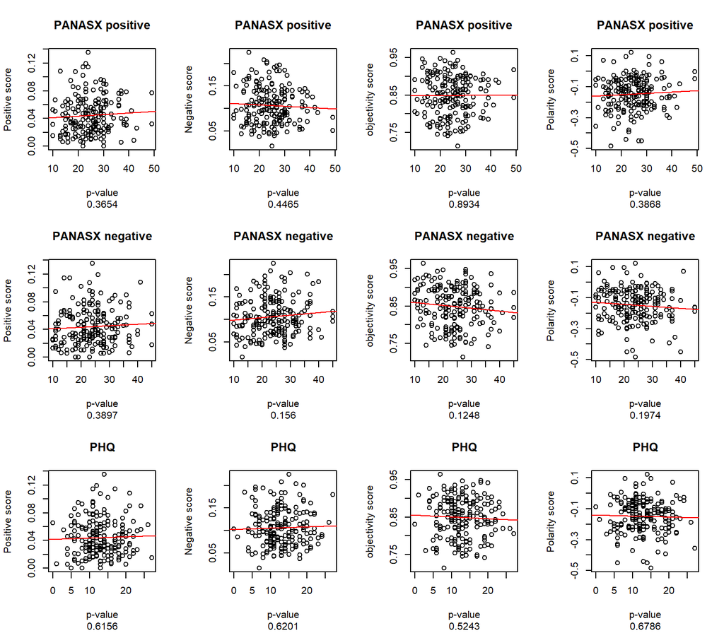

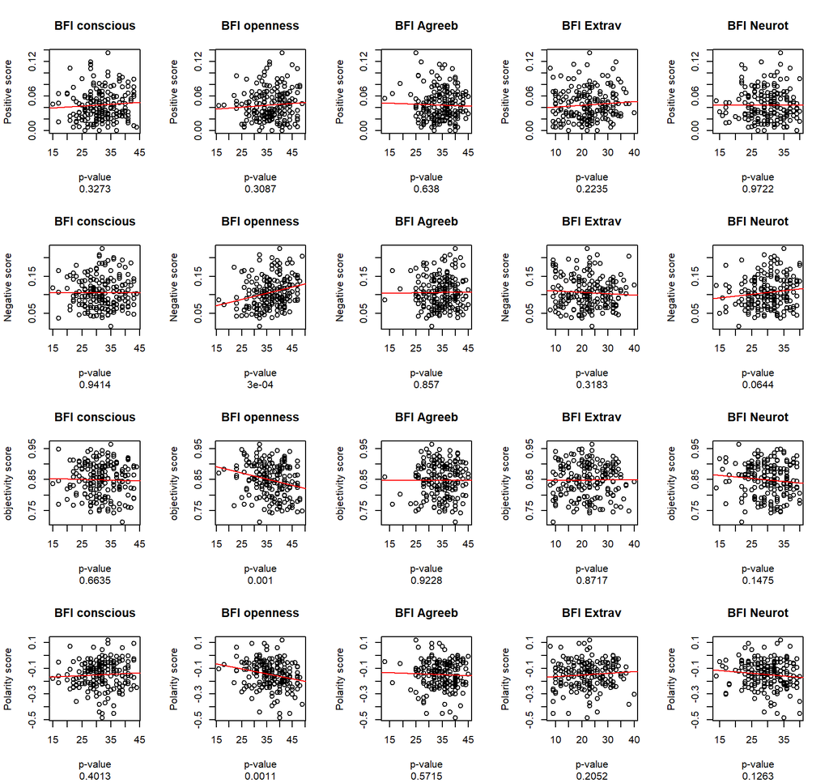

Determine the relationship with respect to the following trait variables: (Symptom scales OASIS), PROMIS (anxiety, depression, anger))

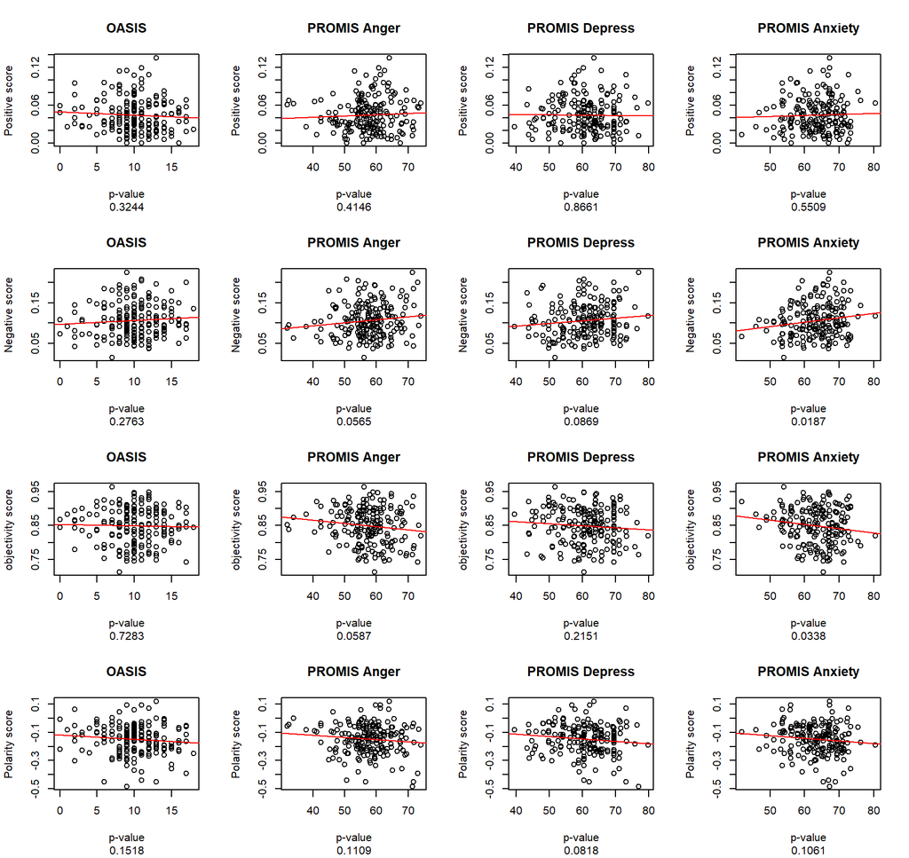

Determine mediating influences (CTQ, TEC)on dependent measured scores

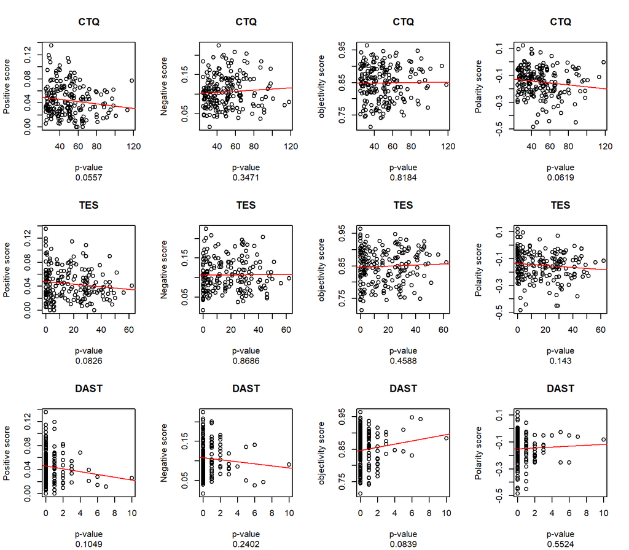